# What Influences Life Expectancy?

Jingqi Kou(jingqik2); Zhan Shi(zhans5); Lang Zhou(langz2); Yiyang Li(yiyang18)

12/12/2020

# Introduction

In this data analysis project, we explored the data set on [Kaggle] (https://www.kaggle.com/kumarajarshi/life-expectancy-who), which is mainly about life expectancy in 193 countries from 2000 to 2015 And unique factors related to health. Contains 2938 observations and 20 predictors, which can be divided into 4

Categories: immune-related factors, mortality factors, economic factors and social factors.

Our main goal is to build a model that is as accurate as possible to analyze the factors that affect life span. These attributes are represented by a wide range of variables in the data set, including everything from adult mortality and government expenditures.

# Methods

## Data Preparation

First, we load the training data and extract the number of samples and the feature names:

```r
train_data = read.csv('Life Expectancy Data.csv')
n = nrow(train_data)
features = setdiff(colnames(train_data), c("Adult Mortality", "percentage expenditure"))
```

The dataset includes **22 features** and **2938 samples.**

# Dealing with Missing Predictor Values

Naturally, we expect that some examples are missing features, let’s try removing those samples and see how much data we’d have left to work with:

```r
train_data_omit_na = na.omit(train_data)
nrow(train_data_omit_na)
```

```
## [1] 1649
```

```r
other_category = 'other'
for (f in features) {
  if (is.factor(train_data[[f]]) && any(is.na(train_data[[f]]))) {
    levels(train_data[[f]]) = c(levels(train_data[[f]]), other_category)
    train_data[[f]][is.na(train_data[[f]])] = other_category
  }
}
# Try omitting samples with missing features again:
train_data_omit_na = na.omit(train_data)
nrow(train_data_omit_na)
```

```
## [1] 1649
```

Let’s see which features have missing values:

```r
Filter(function (f) any(is.na(train_data[[f]])), features)
```

```
##  [1] "Life.expectancy"                 "Adult.Mortality"
##  [3] "Alcohol"                         "Hepatitis.B"
##  [5] "BMI"                             "Polio"
##  [7] "Total.expenditure"               "Diphtheria"
##  [9] "GDP"                             "Population"
## [11] "thinness..1.19.years"            "thinness.5.9.years"
## [13] "Income.composition.of.resources" "Schooling"
```

We decide to omit the missing values and obtain the new dataset called data.

```r
#We omit the rows with missing values
data = na.omit(train_data)
```

# Further Analysis

```r
#Viewing the New Data Frame
print(str(data))
```

```
## 'data.frame':    1649 obs. of  22 variables:
##  $ Country                        : chr  "Afghanistan" "Afghanistan" "Afghanistan" "Afghanistan" ...
##  $ Year                           : int  2015 2014 2013 2012 2011 2010 2009 2008 2007 2006 ...
##  $ Status                         : chr  "Developing" "Developing" "Developing" "Developing" ...
##  $ Life.expectancy                : num  65 59.9 59.9 59.5 59.2 58.8 58.6 58.1 57.5 57.3 ...
##  $ Adult.Mortality                : int  263 271 268 272 275 279 281 287 295 295 ...
##  $ infant.deaths                  : int  62 64 66 69 71 74 77 80 82 84 ...
##  $ Alcohol                        : num  0.01 0.01 0.01 0.01 0.01 0.01 0.01 0.03 0.02 0.03 ...
##  $ percentage.expenditure         : num  71.3 73.5 73.2 78.2 7.1 ...
##  $ Hepatitis.B                    : int  65 62 64 67 68 66 63 64 63 64 ...
##  $ Measles                        : int  1154 492 430 2787 3013 1989 2861 1599 1141 1990 ...
##  $ BMI                            : num  19.1 18.6 18.1 17.6 17.2 16.7 16.2 15.7 15.2 14.7 ...
##  $ under.five.deaths              : int  83 86 89 93 97 102 106 110 113 116 ...
##  $ Polio                          : int  6 58 62 67 68 66 63 64 63 58 ...
##  $ Total.expenditure              : num  8.16 8.18 8.13 8.52 7.87 9.2 9.42 8.33 6.73 7.43 ...
##  $ Diphtheria                     : int  65 62 64 67 68 66 63 64 63 58 ...
##  $ HIV.AIDS                       : num  0.1 0.1 0.1 0.1 0.1 0.1 0.1 0.1 0.1 0.1 ...
##  $ GDP                            : num  584.3 612.7 631.7 670 63.5 ...
##  $ Population                     : num  33736494 327582 31731688 3696958 2978599 ...
##  $ thinness..1.19.years           : num  17.2 17.5 17.7 17.9 18.2 18.4 18.6 18.8 19 19.2 ...
##  $ thinness.5.9.years             : num  17.3 17.5 17.7 18 18.2 18.4 18.7 18.9 19.1 19.3 ...
##  $ Income.composition.of.resources: num  0.479 0.476 0.47 0.463 0.454 0.448 0.434 0.433 0.415 0.405 ...
##  $ Schooling                      : num  10.1 10 9.9 9.8 9.5 9.2 8.9 8.7 8.4 8.1 ...
##  - attr(*, "na.action")= 'omit' Named int [1:1289] 33 45 46 47 48 49 58 59 60 61 ...
##   ..- attr(*, "names")= chr [1:1289] "33" "45" "46" "47" ...
## NULL
```

Then, we coerce Status, Country and Year variables to be factor variables.

```r
is.factor(data$Status)
```

```
## [1] FALSE
```

```r
is.factor(data$Country)
```

```
## [1] FALSE
```

```r
is.factor(data$Year)
```

```
## [1] FALSE
```

```r
data$Country = as.factor(data$Country)
data$Status = as.factor(data$Status)
data$Year = as.factor(data$Year)
print(str(data))
```

```
## 'data.frame':    1649 obs. of  22 variables:
##  $ Country                        : Factor w/ 133 levels "Afghanistan",..: 1 1 1 1 1 1 1 1 1 1 ...
##  $ Year                           : Factor w/ 16 levels "2000","2001",..: 16 15 14 13 12 11 10 9 8 7 ...
##  $ Status                         : Factor w/ 2 levels "Developed","Developing": 2 2 2 2 2 2 2 2 2 2 ...
##  $ Life.expectancy                : num  65 59.9 59.9 59.5 59.2 58.8 58.6 58.1 57.5 57.3 ...
##  $ Adult.Mortality                : int  263 271 268 272 275 279 281 287 295 295 ...
##  $ infant.deaths                  : int  62 64 66 69 71 74 77 80 82 84 ...
##  $ Alcohol                        : num  0.01 0.01 0.01 0.01 0.01 0.01 0.01 0.03 0.02 0.03 ...
##  $ percentage.expenditure         : num  71.3 73.5 73.2 78.2 7.1 ...
##  $ Hepatitis.B                    : int  65 62 64 67 68 66 63 64 63 64 ...
##  $ Measles                        : int  1154 492 430 2787 3013 1989 2861 1599 1141 1990 ...
##  $ BMI                            : num  19.1 18.6 18.1 17.6 17.2 16.7 16.2 15.7 15.2 14.7 ...
##  $ under.five.deaths              : int  83 86 89 93 97 102 106 110 113 116 ...
##  $ Polio                          : int  6 58 62 67 68 66 63 64 63 58 ...
##  $ Total.expenditure              : num  8.16 8.18 8.13 8.52 7.87 9.2 9.42 8.33 6.73 7.43 ...
##  $ Diphtheria                     : int  65 62 64 67 68 66 63 64 63 58 ...
##  $ HIV.AIDS                       : num  0.1 0.1 0.1 0.1 0.1 0.1 0.1 0.1 0.1 0.1 ...
##  $ GDP                            : num  584.3 612.7 631.7 670 63.5 ...
##  $ Population                     : num  33736494 327582 31731688 3696958 2978599 ...
##  $ thinness..1.19.years           : num  17.2 17.5 17.7 17.9 18.2 18.4 18.6 18.8 19 19.2 ...
##  $ thinness.5.9.years             : num  17.3 17.5 17.7 18 18.2 18.4 18.7 18.9 19.1 19.3 ...
##  $ Income.composition.of.resources: num  0.479 0.476 0.47 0.463 0.454 0.448 0.434 0.433 0.415 0.405 ...
##  $ Schooling                      : num  10.1 10 9.9 9.8 9.5 9.2 8.9 8.7 8.4 8.1 ...
##  - attr(*, "na.action")= 'omit' Named int [1:1289] 33 45 46 47 48 49 58 59 60 61 ...
##   ..- attr(*, "names")= chr [1:1289] "33" "45" "46" "47" ...
## NULL
```

We will compare the two models below. For the larger one - model_overall, we use Life.expectancy as the reponse and all the other variables except Country and Year as predictors. For the smaller one - model_select, we pick one representative variable from each factor category in the introduction as the predictors and Life.expectancy still serves as the response.

```r
#Constructing models
model_overall = lm(Life.expectancy ~ . - Country - Year, data = data)
model_select = lm(Life.expectancy ~ Population + GDP + Adult.Mortality + Measles, data = data)
anova(model_select, model_overall)
```

```
## Analysis of Variance Table
##
## Model 1: Life.expectancy ~ Population + GDP + Adult.Mortality + Measles
## Model 2: Life.expectancy ~ (Country + Year + Status + Adult.Mortality +
##     infant.deaths + Alcohol + percentage.expenditure + Hepatitis.B +
##     Measles + BMI + under.five.deaths + Polio + Total.expenditure +
##     Diphtheria + HIV.AIDS + GDP + Population + thinness..1.19.years +
##     thinness.5.9.years + Income.composition.of.resources + Schooling) -
##     Country - Year
##   Res.Df   RSS Df Sum of Sq      F    Pr(>F)
## 1   1644 54840
## 2   1629 20970 15     33870 175.41 < 2.2e-16 ***
## ---
## Signif. codes:  0 '***' 0.001 '**' 0.01 '*' 0.05 '.' 0.1 ' ' 1
```

Based on the results, p-value is $2.2 \times 10^{-16}$ which is very small so we prefer the larger model ‘model_overall’.

```r
summary(model_overall)
```

```
##
## Call:
## lm(formula = Life.expectancy ~ . - Country - Year, data = data)
##
## Residuals:
##      Min       1Q   Median       3Q      Max
## -16.9597  -2.0621  -0.0147   2.2751  11.7115
##
## Coefficients:
##                                   Estimate Std. Error t value Pr(>|t|)
## (Intercept)                      5.445e+01  8.400e-01  64.822  < 2e-16 ***
## StatusDeveloping                -9.684e-01  3.379e-01  -2.865  0.00422 **
## Adult.Mortality                 -1.663e-02  9.494e-04 -17.517  < 2e-16 ***
## infant.deaths                    9.350e-02  1.065e-02   8.777  < 2e-16 ***
## Alcohol                         -9.140e-02  3.316e-02  -2.756  0.00592 **
## percentage.expenditure           3.673e-04  1.801e-04   2.040  0.04156 *
## Hepatitis.B                     -6.525e-03  4.449e-03  -1.467  0.14265
## Measles                         -7.865e-06  1.079e-05  -0.729  0.46597
## BMI                              3.376e-02  5.998e-03   5.628 2.15e-08 ***
## under.five.deaths               -7.035e-02  7.711e-03  -9.123  < 2e-16 ***
## Polio                            7.935e-03  5.152e-03   1.540  0.12370
## Total.expenditure                7.586e-02  4.067e-02   1.865  0.06236 .
## Diphtheria                       1.490e-02  5.928e-03   2.513  0.01205 *
## HIV.AIDS                        -4.370e-01  1.784e-02 -24.490  < 2e-16 ***
## GDP                              8.738e-06  2.837e-05   0.308  0.75813
## Population                      -6.425e-10  1.749e-09  -0.367  0.71337
## thinness..1.19.years            -1.238e-02  5.300e-02  -0.234  0.81527
## thinness.5.9.years              -4.798e-02  5.231e-02  -0.917  0.35917
## Income.composition.of.resources  9.817e+00  8.321e-01  11.797  < 2e-16 ***
## Schooling                        8.665e-01  5.940e-02  14.587  < 2e-16 ***
## ---
## Signif. codes:  0 '***' 0.001 '**' 0.01 '*' 0.05 '.' 0.1 ' ' 1
##
## Residual standard error: 3.588 on 1629 degrees of freedom
## Multiple R-squared:  0.8356, Adjusted R-squared:  0.8336
## F-statistic: 435.7 on 19 and 1629 DF,  p-value: < 2.2e-16
```

Here, we notice that variables including Hepatitis.B, Measles, Polio, Total.expenditure, GDP, Population, thinness..1.19.years, thinness.5.9.years are not significant because of larger p-values. Next, we will construct the model by removing those insignificant variables.

```r
model_overall_reduced = lm(Life.expectancy ~ . - Country - Year - Hepatitis.B - Measles - Polio - GDP- Population-thinness..1.19.years- thinness.5.9.years - Total.expenditure, data = data)
anova(model_overall_reduced, model_overall)
```

```
## Analysis of Variance Table
##
## Model 1: Life.expectancy ~ (Country + Year + Status + Adult.Mortality +
##     infant.deaths + Alcohol + percentage.expenditure + Hepatitis.B +
##     Measles + BMI + under.five.deaths + Polio + Total.expenditure +
##     Diphtheria + HIV.AIDS + GDP + Population + thinness..1.19.years +
##     thinness.5.9.years + Income.composition.of.resources + Schooling) -
##     Country - Year - Hepatitis.B - Measles - Polio - GDP - Population -
##     thinness..1.19.years - thinness.5.9.years - Total.expenditure
## Model 2: Life.expectancy ~ (Country + Year + Status + Adult.Mortality +
##     infant.deaths + Alcohol + percentage.expenditure + Hepatitis.B +
##     Measles + BMI + under.five.deaths + Polio + Total.expenditure +
##     Diphtheria + HIV.AIDS + GDP + Population + thinness..1.19.years +
##     thinness.5.9.years + Income.composition.of.resources + Schooling) -
##     Country - Year
##   Res.Df   RSS Df Sum of Sq     F Pr(>F)
## 1   1637 21140
## 2   1629 20970  8    170.34 1.654 0.1051
```

The p-value which is large verifies our decision to use the model without the insignificant variables.

Next, we will check the collinearity.

```r
vif(model_overall_reduced)
```

```
##                StatusDeveloping                 Adult.Mortality
##                        1.809006                        1.793934
##                   infant.deaths                         Alcohol
##                      183.794662                        2.211584
##          percentage.expenditure                             BMI
##                        1.381962                        1.551690
##               under.five.deaths                      Diphtheria
##                      185.244370                        1.215661
##                        HIV.AIDS Income.composition.of.resources
##                        1.456903                        2.931621
##                       Schooling
##                        3.429247
```

Based on the result, we notice that there is a collinearity issue between infant deaths and under.five.deaths so we will construct a new model by removing the variable ‘infant.deaths’.

```r
model_overall_reduced_infant.deaths = lm(Life.expectancy ~ . - Country - Year - Hepatitis.B - Measles - Polio - GDP- Population-thinness..1.19.years- thinness.5.9.years - Total.expenditure - infant.deaths, data = data)
```

Next, we will check whether this new model violates any assumption.

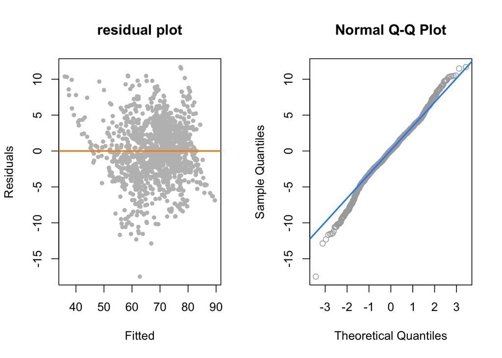

```r
par(mfrow=c(1,2))
plot(fitted(model_overall_reduced_infant.deaths), resid(model_overall_reduced_infant.deaths), col = "grey", pch = 20,
     xlab = "Fitted", ylab = "Residuals", main = "residual plot")
abline(h = 0, col = "darkorange", lwd = 2)

qqnorm(resid(model_overall_reduced_infant.deaths), main = "Normal Q-Q Plot", col = "darkgrey")
qqline(resid(model_overall_reduced_infant.deaths), col = "dodgerblue", lwd = 2)
```

```r
bptest(model_overall_reduced_infant.deaths)
```

```
##
##  studentized Breusch-Pagan test
##
## data:  model_overall_reduced_infant.deaths
## BP = 206.36, df = 10, p-value < 2.2e-16
```

```r
shapiro.test(resid(model_overall_reduced_infant.deaths))
```

```
##
##  Shapiro-Wilk normality test
##
## data:  resid(model_overall_reduced_infant.deaths)
## W = 0.9904, p-value = 6.055e-09
```

Based on the plots, both constant assumption and normality assumption are violated.

Then, we decide to use quadratic transformation for the predictor variables to see whether this situation can be improved.

```r
model_overall_reduced_trans = lm(Life.expectancy ~ . - Country - Year - Hepatitis.B - Measles - Polio - GDP- Population-thinness..1.19.years- thinness.5.9.years - Total.expenditure - infant.deaths + I(Adult.Mortality ^ 2), data = data)
```

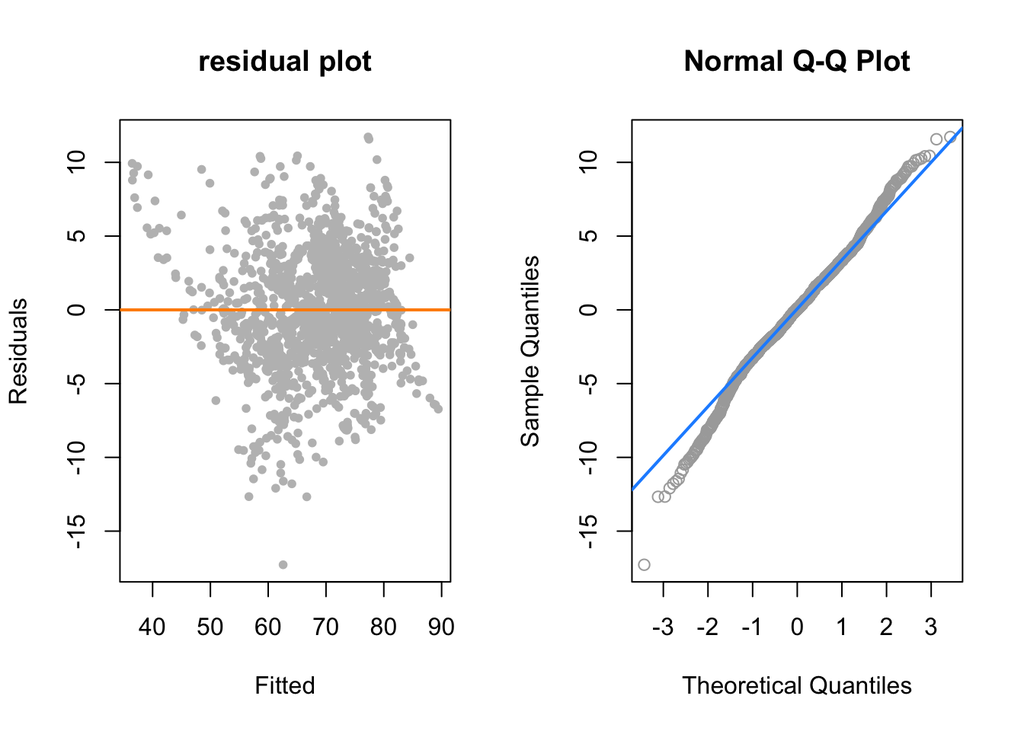

```r
par(mfrow=c(1,2))
plot(fitted(model_overall_reduced_trans), resid(model_overall_reduced_trans), col = "grey", pch = 20,
     xlab = "Fitted", ylab = "Residuals", main = "residual plot")
abline(h = 0, col = "darkorange", lwd = 2)

qqnorm(resid(model_overall_reduced_trans), main = "Normal Q-Q Plot", col = "darkgrey")
qqline(resid(model_overall_reduced_trans), col = "dodgerblue", lwd = 2)
```

We don’t see any improvements after the transformation on the predictor variables so we will check for any influential observations.

```r
model_cook = cooks.distance(model_overall_reduced_infant.deaths)
model_cook[model_cook > 4/length(model_cook)]
```

```
##          14          50          51          53          54          55
## 0.002654522 0.003750214 0.003752147 0.002665017 0.003546917 0.005808540
##          56          57         114         115         116         117
## 0.003330720 0.003299781 0.008127346 0.008130994 0.007877314 0.005901534
##         118         124         133         242         294         295
## 0.002474256 0.002479619 0.003457277 0.003010112 0.007324634 0.005374253
##         296         297         298         299         300         301
## 0.004961282 0.004617583 0.004286296 0.003869996 0.003550505 0.002917120
##         302         304         331         332         340         351
## 0.002521658 0.003095523 0.018704170 0.018400549 0.002639974 0.003417965
##         352         410         419         422         424         486
## 0.003994953 0.003288038 0.002960212 0.003201590 0.003236820 0.003684584
##         491         504         576         633         760         836
## 0.008488727 0.003221892 0.002556233 0.003027119 0.005555390 0.005519976
##         856         858         862         863         864         900
## 0.002925377 0.004480992 0.003677727 0.003725632 0.007514884 0.002677635
##         935         936         938         939         940         994
## 0.002501364 0.002601120 0.006809932 0.005619383 0.002859228 0.017785054
##         996         998         999        1082        1191        1192
## 0.002545755 0.004699991 0.003748233 0.002928321 0.003177975 0.004716274
##        1197        1198        1294        1380        1381        1382
## 0.011666162 0.014240379 0.002694406 0.002834686 0.003020730 0.002932879
##        1383        1384        1385        1386        1391        1394
## 0.002999257 0.002778876 0.002623940 0.002549101 0.005031518 0.002573567
##        1469        1470        1471        1472        1473        1474
## 0.011404480 0.010489232 0.003932043 0.003140053 0.006837288 0.005352461
##        1479        1486        1487        1534        1543        1544
## 0.007556265 0.003204436 0.003452964 0.002523300 0.006345350 0.002785306
##        1546        1548        1574        1581        1584        1629
## 0.021055090 0.004158200 0.004304775 0.013299425 0.018535181 0.003803059
##        1768        1769        1770        1771        1772        1775
## 0.002479260 0.002875997 0.002690972 0.003932744 0.002748992 0.007107275
##        1779        1880        1895        1896        1897        1898
## 0.003531443 0.004049975 0.003765534 0.002611298 0.002568127 0.002748479
##        1899        1900        1903        1904        2057        2058
## 0.002967782 0.003262111 0.003415147 0.029037197 0.011187790 0.004598785
##        2134        2145        2150        2162        2164        2297
## 0.002506640 0.004061436 0.002744093 0.003329123 0.005326488 0.015262432
##        2299        2300        2301        2302        2303        2304
## 0.006237901 0.004409117 0.003863734 0.003444667 0.003593651 0.004148917
##        2305        2306        2397        2434        2497        2499
## 0.004317427 0.015161259 0.003526648 0.003963031 0.010319426 0.013436234
##        2503        2504        2505        2622        2654        2722
## 0.032402868 0.030463250 0.025440171 0.002865257 0.003179567 0.003403195
##        2723        2724        2727        2732        2853        2854
## 0.003788896 0.004581523 0.011220545 0.002553615 0.007061660 0.006522363
##        2855        2856        2857        2858        2914        2931
## 0.006847795 0.012883030 0.012498140 0.003502205 0.003704260 0.010804821
##        2932        2934        2935        2936        2937        2938
## 0.017391290 0.003587205 0.005726624 0.006093815 0.012910225 0.016685964
```

Then, we will refit the model without points we identified as influential.

```r
new_data = data[model_cook <= 4/length(model_cook),]
model_refit = lm(Life.expectancy ~ . - Country - Year - Hepatitis.B - Measles - Polio - GDP- Population-thinness..1.19.years- thinness.5.9.years - Total.expenditure - infant.deaths, data = new_data)
```

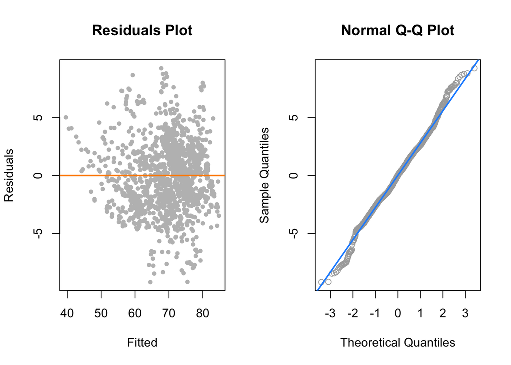

```r
par(mfrow=c(1,2))
plot(fitted(model_refit), resid(model_refit), col = "grey", pch = 20,
     xlab = "Fitted", ylab = "Residuals", main = "Residuals Plot")
abline(h = 0, col = "darkorange", lwd = 2)

qqnorm(resid(model_refit), main = "Normal Q-Q Plot", col = "darkgrey")
qqline(resid(model_refit), col = "dodgerblue", lwd = 2)
```

We see that residuals plot and Q-Q plot get better so we use model_refit as our final model.

# Results

We decide to use Status, Adult.Mortality, Alcohol, percentage.expenditure, BMI, under.five.deaths, Diphtheria, HIV.AIDS, Income.composition.of.resources, Schooling as predictors and Life.expectancy as response to construct the final model.

```r
final_model = model_refit
summary(final_model)
```

```
##
## Call:
## lm(formula = Life.expectancy ~ . - Country - Year - Hepatitis.B -
##     Measles - Polio - GDP - Population - thinness..1.19.years -
##     thinness.5.9.years - Total.expenditure - infant.deaths, data = new_data)
##
## Residuals:
##     Min      1Q  Median      3Q     Max
## -9.2077 -1.8592  0.0135  1.8963  9.2609
##
## Coefficients:
##                                   Estimate Std. Error t value Pr(>|t|)
## (Intercept)                      5.437e+01  6.613e-01  82.217  < 2e-16 ***
## StatusDeveloping                -2.936e-01  2.759e-01  -1.064  0.28741
## Adult.Mortality                 -2.149e-02  8.869e-04 -24.233  < 2e-16 ***
## Alcohol                         -7.265e-02  2.732e-02  -2.659  0.00793 **
## percentage.expenditure           4.154e-04  5.687e-05   7.304 4.55e-13 ***
## BMI                              3.413e-02  4.728e-03   7.219 8.34e-13 ***
## under.five.deaths               -1.390e-03  5.908e-04  -2.353  0.01877 *
## Diphtheria                       2.087e-02  3.886e-03   5.371 9.10e-08 ***
## HIV.AIDS                        -4.150e-01  1.852e-02 -22.411  < 2e-16 ***
## Income.composition.of.resources  1.658e+01  9.902e-01  16.745  < 2e-16 ***
## Schooling                        5.107e-01  5.679e-02   8.994  < 2e-16 ***
## ---
## Signif. codes:  0 '***' 0.001 '**' 0.01 '*' 0.05 '.' 0.1 ' ' 1
##
## Residual standard error: 2.839 on 1488 degrees of freedom
## Multiple R-squared:  0.8735, Adjusted R-squared:  0.8726
## F-statistic:  1027 on 10 and 1488 DF,  p-value: < 2.2e-16
```

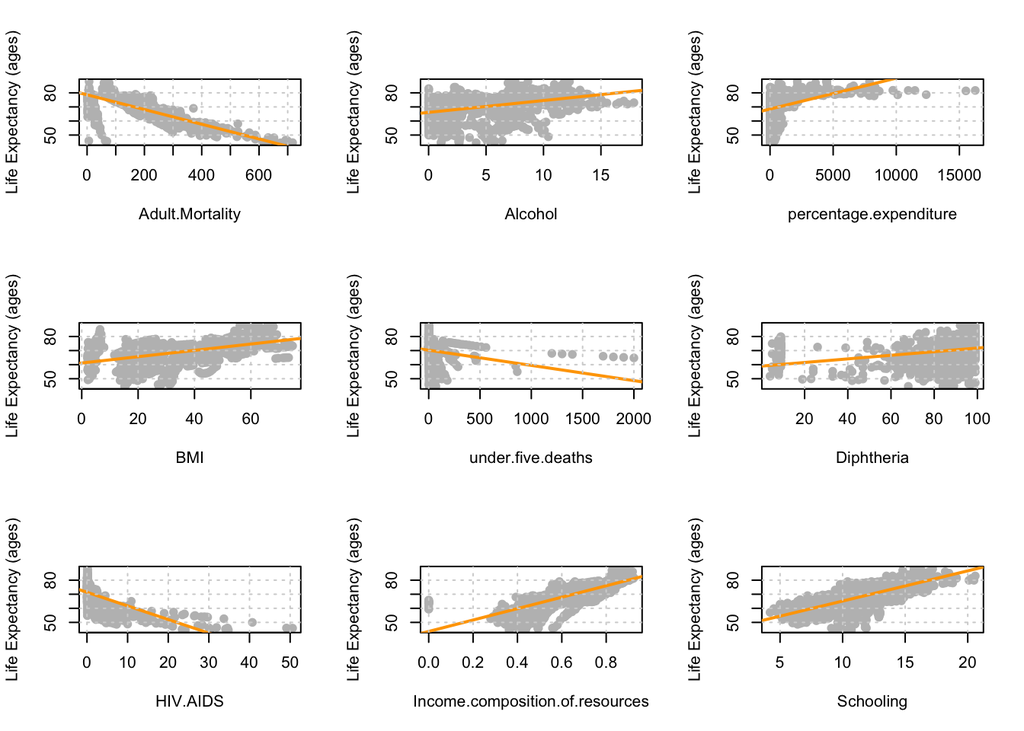

```r
par(mfrow = c(3,3))
plot(Life.expectancy ~ Adult.Mortality, data = new_data, xlab = "Adult.Mortality", ylab = "Life Expectancy (ages)", col = "grey", pch  = 20, cex  = 1.5)
abline(lm(Life.expectancy ~ Adult.Mortality, data = new_data), col = "orange", lwd = 2)
grid()

plot(Life.expectancy ~ Alcohol, data = new_data, xlab = "Alcohol", ylab = "Life Expectancy (ages)", col = "grey", pch  = 20, cex  = 1.5)
abline(lm(Life.expectancy ~ Alcohol, data = new_data), col = "orange", lwd = 2)
grid()

plot(Life.expectancy ~ percentage.expenditure, data = new_data, xlab = "percentage.expenditure", ylab = "Life Expectancy (ages)", col = "grey", pch  = 20, cex  = 1.5)
abline(lm(Life.expectancy ~ percentage.expenditure, data = new_data), col = "orange", lwd = 2)
grid()

plot(Life.expectancy ~ BMI, data = new_data, xlab = "BMI", ylab = "Life Expectancy (ages)", col = "grey", pch  = 20, cex  = 1.5)
abline(lm(Life.expectancy ~ BMI, data = new_data), col = "orange", lwd = 2)
grid()

plot(Life.expectancy ~ under.five.deaths, data = new_data, xlab = "under.five.deaths", ylab = "Life Expectancy (ages)", col = "grey", pch  = 20, cex  = 1.5)
abline(lm(Life.expectancy ~ under.five.deaths, data = new_data), col = "orange", lwd = 2)
grid()

plot(Life.expectancy ~ Diphtheria, data = new_data, xlab = "Diphtheria", ylab = "Life Expectancy (ages)", col = "grey", pch  = 20, cex  = 1.5)
abline(lm(Life.expectancy ~ Diphtheria, data = new_data), col = "orange", lwd = 2)
grid()

plot(Life.expectancy ~ HIV.AIDS, data = new_data, xlab = "HIV.AIDS", ylab = "Life Expectancy (ages)", col = "grey", pch  = 20, cex  = 1.5)
abline(lm(Life.expectancy ~HIV.AIDS, data = new_data), col = "orange", lwd = 2)
grid()


plot(Life.expectancy ~ Income.composition.of.resources, data = new_data, xlab = "Income.composition.of.resources", ylab = "Life Expectancy (ages)", col = "grey", pch  = 20, cex  = 1.5)
abline(lm(Life.expectancy ~Income.composition.of.resources, data = new_data), col = "orange", lwd = 2)
grid()


plot(Life.expectancy ~ Schooling, data = new_data, xlab = "Schooling", ylab = "Life Expectancy (ages)", col = "grey", pch  = 20, cex  = 1.5)
abline(lm(Life.expectancy ~ Schooling, data = new_data), col = "orange", lwd = 2)
grid()
```

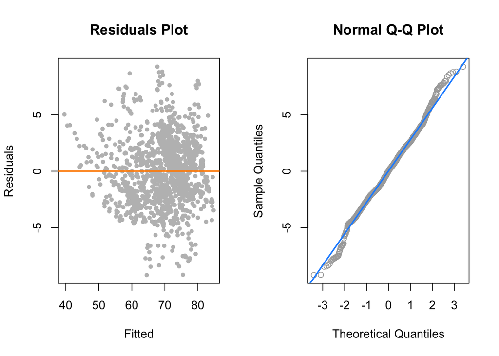

```r
par(mfrow=c(1,2))
plot(fitted(final_model), resid(final_model), col = "grey", pch = 20,
     xlab = "Fitted", ylab = "Residuals", main = "Residuals Plot")
abline(h = 0, col = "darkorange", lwd = 2)

qqnorm(resid(final_model), main = "Normal Q-Q Plot", col = "darkgrey")
qqline(resid(final_model), col = "dodgerblue", lwd = 2)
```

***

# Discussion